# How to Pull the Right Lever

School Attainment, Open Data Analytics and Policy in England — Lessons from Brighton and Hove (v2.0)

Adam Dennett

Bartlett Centre for Advanced Spatial Analysis, UCL

2026-10-14

## Who am I?

- Professor of Urban Analytics @ CASA, UCL
  - Data, Urban Policy, Quantitative Methods, Maps
- Former State Secondary School Geography Teacher
- Brighton Resident and Parent
- Lifelong Labour voter and former party member

## Why are we all here?

- I made you come
- An awareness of controversial changes to secondary admissions in the city over the last 2-years
- An interest in schools and educational attainment more generally
- An interest in supporting disadvantaged students to achieve
- An interest in data and evidence-based policy making
- You’ve read my report and want to ask some questions
  - Or took one look at the length of it and thought it easier to hear me talk about it
- A good opportunity to throw something at me

## First — today’s response from Class Divide

Class Divide have published a thoughtful response to this report today. I am grateful for it — they have spent six years working on exactly the barriers this talk is about, and we share the same goal.

- We agree on far more than we differ on:
  - **Poverty is foundational** — the attainment gap has many tangled causes
  - **Absence matters enormously** — and much of it *is* poverty: bus fares, unmet special educational needs, ill health
  - Outcomes for our poorest children — in Whitehawk especially — are **not good enough**

## Where we differ — and it is narrow

- My question is deliberately narrow: in a city *already* among the most integrated in England, does moving children between schools deliver enough **attainment** gain to justify the certain cost to the children who move?
- The disruption is **certain, and now**; the benefit is **uncertain** - looking at the data helps us reduce that uncertainty. The burden of proof sits with the intervention.
- And it is *not* “almost no cost”: moving children further afield lengthens daily journeys — and longer journeys mean **more absence** (my own report shows this), borne hardest by the poorest. That is the very lever we all agree matters most.
- Absence (which I will talk about a lot) is not an *“unfixable excuse”* - if all schools in the city had the same absence levels as the city’s best, it would make a huge dent in the disadvantage attainment gap.
- This is, in the end, partly a question of **values** as well as evidence - but this talk is concerned principally with the evidence.

## The Report

[figure not shown]

[figure not shown]

## Headlines

- Over the last 4-years, *after accounting for structural factors*, Brighton and Hove ranks (out of 151 LEAs in England):
  - **15th BEST** for Disadvantaged GCSE Attainment
  - **4th BEST** for Non-Disadvantaged GCSE Attainment
- Last year, Brighton and Hove was **2nd WORST** for absence.
- Control for absence and the city ranks 15th; leave it out and it ranks 69th. That gap — about 1.4 GCSE points per pupil — is what absence costs the city’s disadvantaged children.
- GCSE Attainment is very predictable at School Level - 80% variation between schools explained by a handful of variables
- The biggest factor affecting disadvantaged student attainment is absence
- Data shows disadvantaged students in England do better in schools with more disadvantaged students in
- *Poor* understanding of evidence → *poor* policy → *poor* parental choices

# Motivation & Context

## Why this report now?

- The UK Government’s **2026 “Every child achieving and thriving” White Paper** sets ambitious targets:
  - Halve the *disadvantage attainment gap* — **~15 Attainment 8 points today**
  - Improve attendance
  - Reform admissions
  - Tackle place-based disadvantage
- Achieving these requires LEAs to understand the **national picture** and **local situation** simultaneously
- This paper is motivated by **direct experience** of policy development in Brighton and Hove in 2024–25

**The problem:** A crucial gap exists between the *availability of open data* and the *availability of accessible*, contextualised intelligence for decision makers.

**The risk:** Policy designed around an incomplete understanding of local situation can pull the wrong lever — doing little good and potentially causing harm in the process.

## What is the report trying to do?

1. Halve the *local authority intelligence gap* - following the report present a **Policy Simulator tool** that bridges the gap between data and intelligence for decision making
2. Convince you that attainment levels are very predictable - show that **DfE open data** can explain ~80% of variation in school-level attainment with just a handful of variables
3. Demonstrate the **relative importance** of different policy levers — and reveal which ones actually have mechanical advantage
4. Re-calibrate how we view *‘good schools’* - and convince you that most of what many conflate with good schools (their outcomes), is out of their hands
5. Use **Brighton and Hove** as a case study to illustrate all of these issues

We are **not** claiming the best possible model — we are showing that *good enough* models built from open data can transform the quality of local policy conversations.

## Schools vs circumstances: a sixty-year argument

- **The Coleman Report (US, 1966)**: family background and peers explain far more of attainment than anything schools do — a finding that shocked policymakers (reinforced by Jencks, *Inequality*, 1972)
- **The British response**: Rutter et al., *Fifteen Thousand Hours* (1979); Mortimore et al., *School Matters* (1988) — schools **do** differ, measurably → the birth of **school effectiveness research**
- **The settled consensus**: school effects are real but a minority share — **~10%** of achievement variance at school level in the landmark UK studies (Teddlie & Reynolds’s 2000 summary of Smith & Tomlinson, 1989), with early field estimates of **12–15%** (Reynolds et al., 2014); intake and context carry the rest

“Context outweighs school” is a sixty-year-old finding — what has been missing is a way to make it **usable**. This work makes the decomposition open, reproducible and *local* — and later in this deck, puts today’s numbers on it.

## What drives attainment at GCSE? The literature

- **Attendance**: strongest predictor — persistently absent pupils: 36% pass rate vs 84% for full attenders (DfE, 2022, 2025)
- **Prior attainment** at KS2: reflects accumulated earlier inequalities (Gorard and Siddiqui, 2019; Stopforth and Gayle, 2025)
- **Disadvantage** (FSM): some residual effect remains after accounting for above. Gap narrowed post-2011, reversed post-COVID (Tuckett et al., 2023)
- **Workforce**: leadership quality, teacher retention, and teacher sickness matter — especially for disadvantaged pupils (Gibbons et al., 2018; Menzies, 2023; Zuccollo et al., 2023)
- **Selectivity**: creams-off rather than improves - grammar school premium largely disappears after SES controls (Anders et al., 2024; Gorard et al., 2022; Gorard and Siddiqui, 2019)
- **Individual Pupil characteristics** (Houtepen et al., 2020; O’Connell and Marks, 2022)

The factors are **multifaceted, complex and interrelated**. What’s needed is an analysis combining them so their relative importance can be assessed concurrently.

## The challenge of synthesis

- The evidence base is **vast** — many factors, many studies, many interactions
- Hard for anyone to judge which driver is most important *in a particular context*
- Requires analysis that combines drivers **simultaneously** so relative influences can be assessed

**This is exactly what was missing in Brighton and Hove in the 2024 consultation.** A single strand of evidence (segregation) was treated as the whole story, to the exclusion of other — potentially more impactful — factors.

# Brighton and Hove: Context

## The city’s secondary school landscape

[interactive chart not shown]

Figure 1

## 10 secondary schools — a unique admissions system

- **6 community schools** (LEA-controlled), **2 academies** (BACA, PACA), **2 church schools**
- Catchment areas with **lottery tie-break** for oversubscribed schools (since 2008)
  - Replaced distance-based allocation following CoMArt closure
  - Very unusual in England
- In 2023, FSM priority added — **already affecting mixing** without opposition
- Brighton & Hove is already in the **top 1/4 of LEAs nationally** for integration of disadvantaged/non-disadvantaged pupils

## The 2024 consultation: the proposals

**What was proposed:**

- Reduce PANs at popular central schools (Blatchington Mill, Dorothy Stringer)
- Reserve **20%** of places for out-of-catchment children
- Redraw catchment boundaries in the east

**Council’s stated objectives** (Dec 2024 Cabinet papers):

> *“reducing some schools’ barriers to success”* for disadvantaged pupils

> *“a more mixed pupil intake creates better outcomes for disadvantaged pupils”*

**Stated premise:** results in the city were *“driven by economic advantage”* — so redistribute → narrow the gap

## An aside on economic advantage and house prices

- Being close to a good secondary school has *barely any effect* on house prices in Brighton and Hove
- We examined *81,000* residential property transactions over *20 years* (2000-2019) in Brighton and Hove and looked at the factors influencing those prices
- Being within *walking distance of a mainline train station* or a *short bus ride to the city centre* **far more important** for house prices than being close to a good secondary school

[figure not shown]

[figure not shown]

## The 2024 consultation: the response

**Public reaction:**

- *“Strong preference for improving existing schools rather than redistributing students”*
- Concerns about community cohesion and student wellbeing
- National media coverage of vocal objections

**The institutional context:**

- Labour majority + Leader & Cabinet system
- Compressed consultation timeline
- Limited scope for deliberative engagement
- Privileged access for some stakeholder groups over others in *“policy formation”*

## The key questions this raises

1. **Is the premise correct?** Is attainment in Brighton & Hove really “driven by economic advantage”?
2. **Is this the right lever?** Even if concentrations of disadvantage matter, are they the *most important* factor?
3. **How is the city actually performing** once structural factors are accounted for?
4. **What are the risks** of pulling this particular lever — including second-order effects?
5. **Should you even be pulling it -** or pushing it the other way?

We can answer all of these with DfE open data.

# Data & Methods

## DfE open data

**Data sources:**

- School performance (Attainment 8, Progress 8)
- Pupil absence and attendance
- Pupil characteristics (FSM, EAL, prior attainment)
- School workforce (retention, sickness, pay)
- Ofsted ratings
- Admissions policies
- School characteristics

**Our panel:**

- **13,419 school-year observations**
- 3,523 academies and maintained schools
- 152 Local Education Authorities
- 4 academic years (2021–22 to 2024–25)
- Post-COVID, post-imputed grades

All publicly available. All linkable. All underutilised.

## What is the ‘model’?

- Statistical explanation of how GCSE Attainment varies between schools after accounting for things we know affect attainment
- Is the top boat better? Higher performing? Or experiencing more favourable conditions?
- Raw league tables compare finishing positions, our model adjusts for the wind

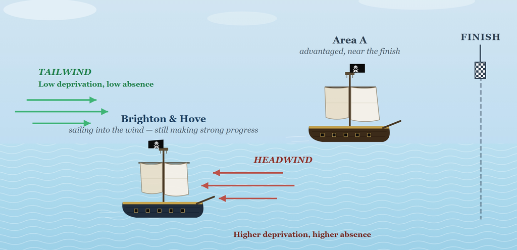

## What is the ‘model’? A fancy multidimensional scatter plot

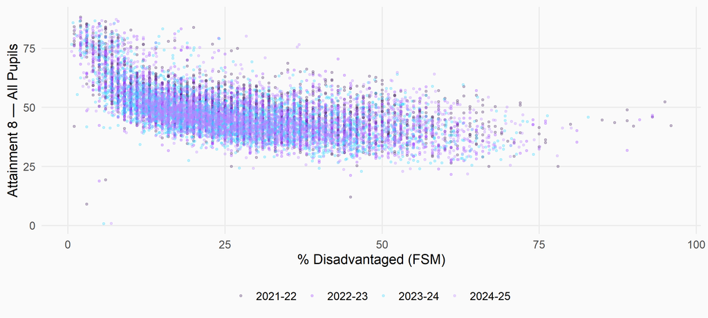

Figure 2

## Non-linear effects and local context matter

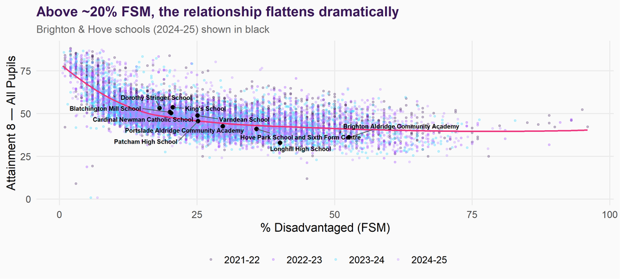

Figure 3

**Where a school or a whole LEA sits on the curve matters enormously for policy.**

## Non-linear effects and local context matter

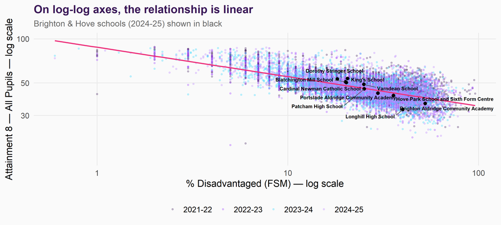

Figure 4

**Logging both axes straightens the curve** — so a single elasticity captures the relationship.

## Model specification

**Multilevel linear mixed effects model** — schools nested within LEAs within regions:

$$\log(\text{ATT8}_{ij}) = \beta_0 + \sum_{k=1}^{9} \beta_k \, x_{kij} + u_{\text{year}} + u_{\text{Ofsted}} + u_{\text{region}} + u_{\text{LA|region}} + \varepsilon_{ij}$$

**Fixed effects (predictors):**

- log(% FSM-eligible)
- log(% Overall absence)
- log(% English as an Additional Language - EAL)
- % Low prior attainment (KS2)
- Selective admissions (dummy)
- Gorard Segregation Index (LA-level)
- Teacher retention rate
- Leadership pay proportion
- log(Teacher sickness days)

**Random effects (grouping):**

- Academic year
- Ofsted rating (4-category)
- Government Office Region
- LEA nested within region

**Three models:**

- All pupils
- Disadvantaged pupils
- Non-disadvantaged pupils

## Model specification

**Multilevel linear mixed effects model** — schools nested within LEAs within regions:

$$\log(\text{ATT8}_{ij}) = \beta_0 + \sum_{k=1}^{9} \beta_k \, x_{kij} + u_{\text{year}} + u_{\text{Ofsted}} + u_{\text{region}} + u_{\text{LA|region}} + \varepsilon_{ij}$$

**Fixed effects (predictors):**

- log(% FSM-eligible)
- log(% Overall absence)
- log(% English as an Additional Language - EAL)
- % Low prior attainment (KS2)
- Selective admissions (dummy)
- Gorard Segregation Index (LA-level)
- Teacher retention rate
- Leadership pay proportion
- log(Teacher sickness days)

**Random effects (grouping):**

- Academic year
- Ofsted rating (4-category)
- Government Office Region
- LEA nested within region

**Three models:**

- All pupils
- Disadvantaged pupils
- Non-disadvantaged pupils

A Statistical Model

# National Results

## How good are the models?

| Model | Marginal R² | Conditional R² |
| --- | --- | --- |
| All pupils | 0.65 | **0.78** |
| Disadvantaged | 0.56 | 0.73 |
| Non-disadvantaged | 0.65 | 0.8 |

$R^2$ measures how much variation in Attainment 8 is explained by the model

**Essentially - How close to the line of best-fit are the points in the scatter-plot?**

Can be interpreted as a % - e.g. 0.8 = 80%

School-level attainment is **remarkably predictable** from a small number of structural factors.

~80% of variation explained for all pupils; ~70–80% for subgroups.

- Disadvantaged pupils: more variation from unmeasured factors (individual resilience, specific interventions)
- Non-disadvantaged: tighter, more predictable

## Mediating Variables

Mediating variables sit on the causal pathway, not including can inflate apparent relationships: *Disadvantage(FSM)* → *Absence* → *Attainment*

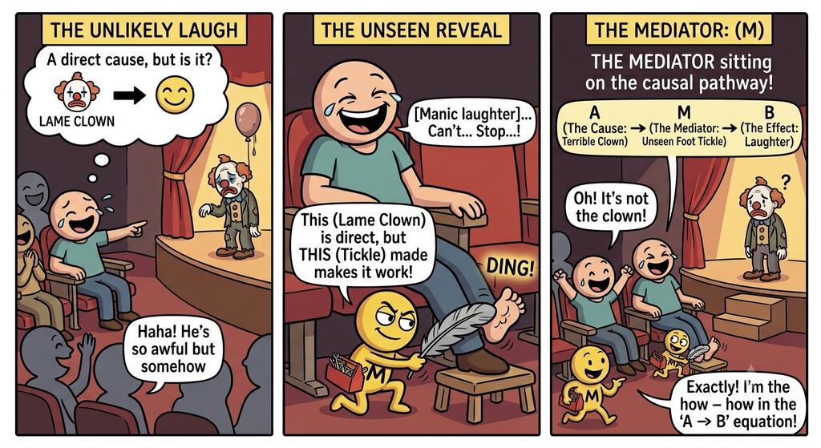

## The mediation story: building the model step by step

Table 1

|  | M1: FSM only | M2: + Absence | M3: + Prior att. |
| --- | --- | --- | --- |
| FSM coefficient | -0.201 | -0.122 | -0.047 |
| Absence coefficient | — | -0.364 | -0.259 |
| Prior att. coefficient | — | — | 0.031 |
| R² | 0.393 | 0.612 | 0.696 |

The coefficient is a number that represents how steep the line through the scatter plot is. Bigger number (positive or negative) → steeper the line → stronger the effect. 0 = flat line = no effect

## Seeing the mediation: the disadvantage line flattens

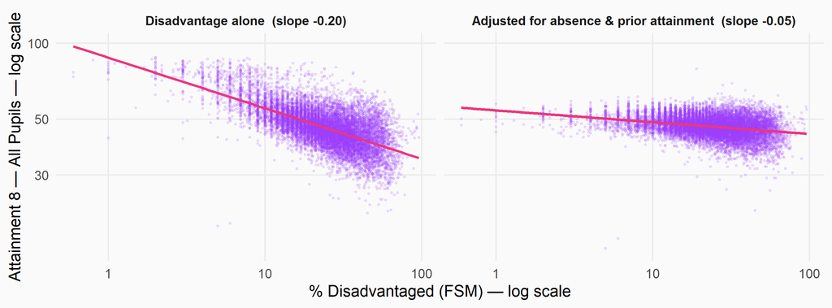

Figure 5

Same schools, same axes — but once absence and prior attainment are held constant (right), the disadvantage line **flattens dramatically**: most of the apparent effect ran *through* attendance and prior attainment.

## What about segregation?

- The Gorard Segregation Index is **not statistically significant** in the full model
- Once a school’s own FSM levels, attendance, prior attainment and geographic location are accounted for → **no additional predictive power**
- Any harm segregation causes is **fully mediated** by the other variables
- This doesn’t mean segregation is harmless — it means its effects **operate through** absence, prior attainment, and other measured factors
- We include it because it formed **much of the justification** for the Brighton & Hove proposals
- Also remember - *Brighton and Hove is in the top 1/4 of LEAs for least segregation / most integration of disadvantaged / non-disadvantaged students already*

## Relative variable importance

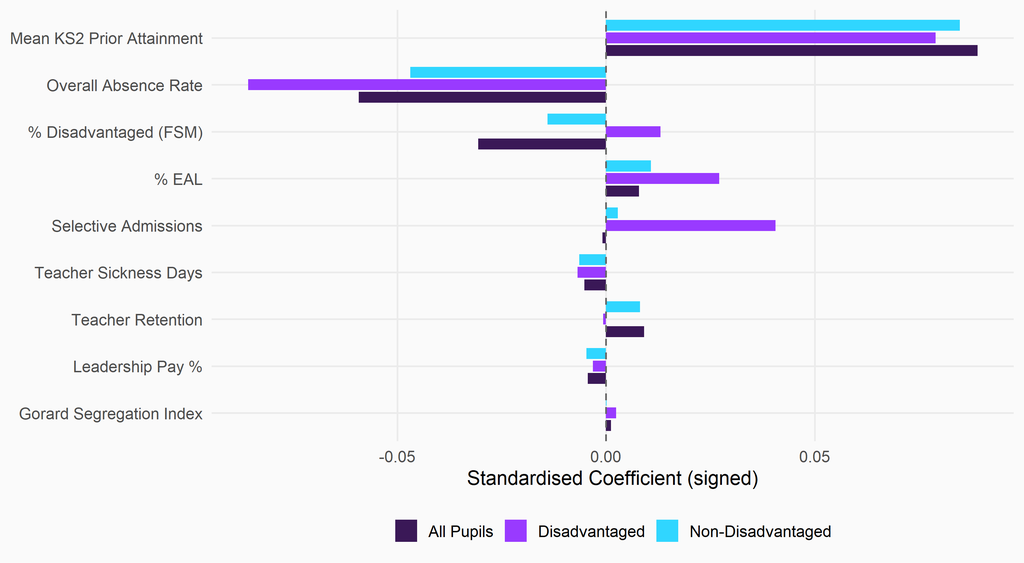

Figure 6

## Key finding: absence dominates

**Absence is the most powerful predictor** of school-level attainment by a considerable margin — its coefficient is roughly **2.6 times larger** than concentrations of disadvantage.

- For **disadvantaged pupils**, nearly half of school-level performance variation is explained by attendance alone
- Absence matters **~1.8× more** (≈77%) for disadvantaged than non-disadvantaged pupils’ attainment
- Disadvantaged pupils lack safety nets (tutors, engaged parents, revision guides) — they are **more reliant on classroom instruction**
- Attendance is the **ultimate equity lever**
- On the council’s own framing — *“reducing some schools’ barriers to success”* for disadvantaged pupils — **attendance is the largest, best-evidenced barrier** the model can quantify

## The contentious finding: concentrations of disadvantage (1)

For **non-disadvantaged** pupils:

- Higher FSM → lower attainment

For **disadvantaged** pupils:

- Higher FSM → *slightly higher* attainment *(opposite BHCC consultation statement)*
- After controlling for absence & prior attainment
- Robust across years and alternative specifications - echos 2015 DfE evidence

**Why?** Schools with higher concentrations likely develop specialised support systems — targeted use of Pupil Premium, vocational pathways, specialist staff.

Effect shrinks in the full multilevel model → operates through LEA/Ofsted factors, not concentration *per se*.

**Impact** Even before negative impacts of redistribution policy (longer journeys etc.), BHCC policy likely to negatively impact disadvantaged attainment at city level.

## The contentious finding: concentrations of disadvantage (2)

- To be clear: We do **not** advocate for active concentration of disadvantaged pupils.
- But deconcentration policies premised on the assumption disadvantaged students inevitably fare worse in higher-disadvantage schools are **not supported by this evidence**.
- Where deconcentration policies create other negative externalities, classic example of *pulling the wrong lever*

# Brighton & Hove: The Evidence

## How is Brighton & Hove actually performing?

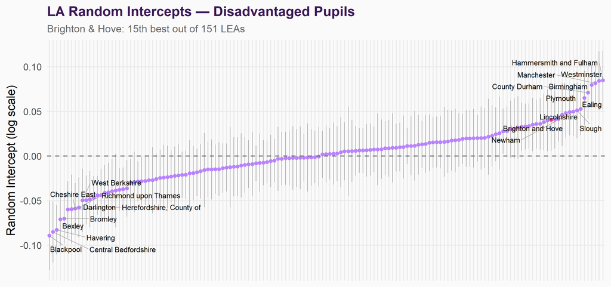

Figure 7

Each dot is one LEA’s average boost (above the dashed line) or penalty (below) to disadvantaged attainment, *after* accounting for intake, absence and prior attainment — i.e. how much better or worse its schools do than the national picture predicts.

## Brighton & Hove: a story of success, not failure

**LEA rankings (after structural adjustment):**

| Pupil group | Rank / 152 |
| --- | --- |
| Disadvantaged | **15th** |
| Non-disadvantaged | **4th** |
| All pupils | **5th** |

The positive random intercept ≈ **+2 GCSE points** above what structural factors predict.

**This was entirely unknown** at the time of the 2024 consultation and completely absent from the public narrative.

The starting point was a narrative of *failure*. The evidence says the opposite: this is one of the **highest-performing LEAs in England**.

Rather than “what is the city doing wrong?”, the question should be **“what is it doing right?”**

## But there is a problem — and it isn’t segregation

**FSM/Disadvantaged Mixing** **(the lever chosen):**

- City mean: 28.8%
- National mean: 28.3%
- National percentile: **52th**
- *Completely unremarkable*

**Absence** **(the lever totally ignored):**

- City mean: 10.8%
- National mean: 8.2%
- National percentile: **99th**
- *Among the very worst in England*

Brighton & Hove has **near-average disadvantage** but **near-worst absence**. The city’s strong underlying performance is being dragged down by an absence problem at the extreme of the national distribution.

## Absence league table - Worst LEAs in England (ranked 2024-25)

Table 2

| Local Authority | 2024-25 | 2023-24 | 2022-23 | 2021-22 |
| --- | --- | --- | --- | --- |
| Knowsley | 10.9% (152/152) | 11.9% (151/152) | 11.8% (149/152) | 12.6% (152/152) |
| Brighton and Hove | 10.8% (151/152) | 11.0% (143/152) | 10.5% (137/152) | 10.8% (144/152) |
| Newcastle upon Tyne | 10.6% (150/152) | 11.4% (150/152) | 12.9% (152/152) | 12.2% (151/152) |
| Southampton | 10.5% (149/152) | 11.0% (145/152) | 10.6% (139/152) | 10.1% (119/152) |
| Bradford | 10.3% (148/152) | 11.2% (147/152) | 11.9% (150/152) | 11.5% (149/152) |
| Plymouth | 10.2% (147/152) | 11.3% (149/152) | 10.8% (144/152) | 11.1% (147/152) |
| Middlesbrough | 10.1% (146/152) | 12.2% (152/152) | 12.9% (151/152) | 11.8% (150/152) |
| Sefton | 10.0% (145/152) | 10.5% (133/152) | 10.3% (129/152) | 10.1% (122/152) |
| Devon | 9.9% (144/152) | 10.8% (139/152) | 10.9% (145/152) | 10.8% (145/152) |
| Dorset | 9.9% (143/152) | 10.7% (137/152) | 10.2% (127/152) | 10.3% (134/152) |
| Halton | 9.8% (142/152) | 11.0% (144/152) | 10.3% (131/152) | 10.1% (118/152) |
| Blackpool | 9.8% (141/152) | 11.3% (148/152) | 11.1% (147/152) | 9.8% (103/152) |
| Hartlepool | 9.8% (140/152) | 10.5% (134/152) | 11.1% (148/152) | 10.2% (130/152) |
| Bristol, City of | 9.6% (135/152) | 11.0% (142/152) | 11.0% (146/152) | 10.6% (141/152) |
| Gateshead | 9.5% (130/152) | 11.2% (146/152) | 10.8% (143/152) | 11.4% (148/152) |
| St. Helens | 9.1% (121/152) | 10.0% (122/152) | 9.6% (103/152) | 10.7% (143/152) |
| Torbay | 8.2% (75/152) | 10.3% (126/152) | 10.2% (125/152) | 10.9% (146/152) |

## Accelerating returns: comparing the two levers

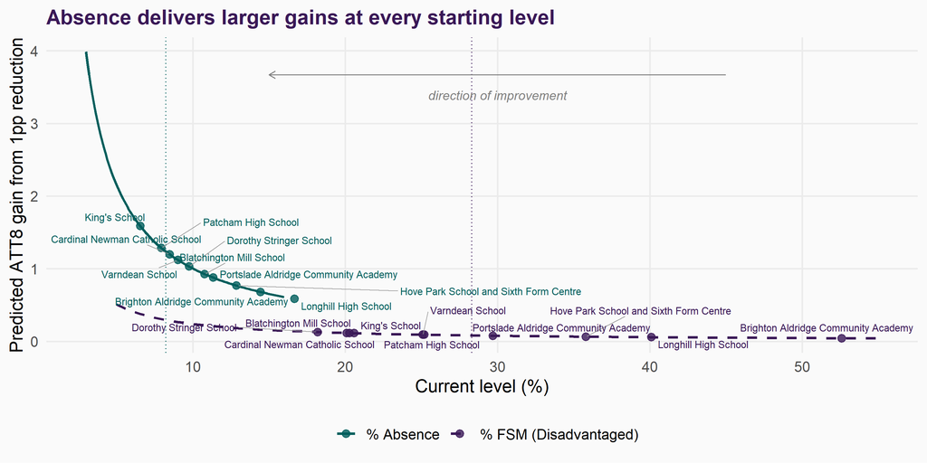

Figure 8

## What would closing the absence gap deliver?

Table 3

| School | Current Absence % | National Avg (Target) | Reduction (pp) | ATT8 gain (all) | ATT8 gain (disadv.) |
| --- | --- | --- | --- | --- | --- |
| Longhill High School | 16.7 | 8.2 | 8.4 | 5.2 | 6.0 |
| Brighton Aldridge Community Academy | 14.4 | 8.2 | 6.2 | 4.5 | 6.1 |
| Hove Park School and Sixth Form Centre | 12.9 | 8.2 | 4.6 | 4.0 | 4.7 |
| Portslade Aldridge Community Academy | 11.3 | 8.2 | 3.1 | 2.9 | 3.1 |
| Blatchington Mill School | 10.8 | 8.2 | 2.6 | 2.9 | 3.2 |
| Dorothy Stringer School | 9.8 | 8.2 | 1.5 | 1.9 | 1.9 |
| Varndean School | 9.0 | 8.2 | 0.8 | 0.9 | 0.9 |
| Cardinal Newman Catholic School | 8.5 | 8.2 | 0.3 | 0.3 | 0.4 |

Bringing absence to the national average → predicted gains of **3–5 GCSE points (even more for disadvantaged)** at the worst-affected schools. FSM reductions → closer to **1–2 points** (and not for disadvantaged students).

## What is a good school?

Schools about much more than raw attainment:

- Centres of pastoral support and places for children to grow as individuals
- *Community hubs* (where they are focal points for local communities)
- Places for extra-curricular opportunities

But in purely attainment terms:

- Is a good school one that simply has high levels of attainment?
- Is a good school one where pupils exceed the levels we would expect, given their circumstances?

## Observed vs predicted: disadvantaged pupils nationally (2024–25)

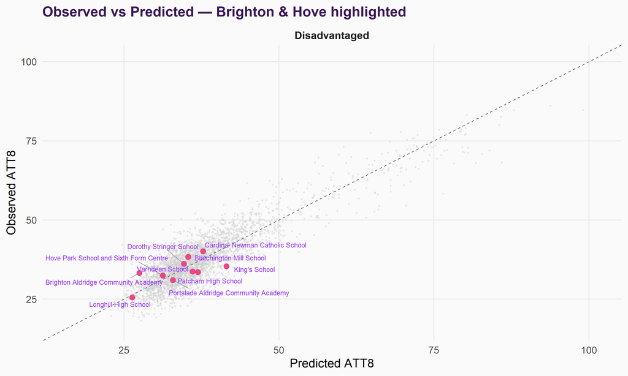

Figure 9

## Alternative league tables: value-added

Disadvantaged Pupils: Value-Added Rankings (ATT8 points vs prediction)

| Rank | School | 2021-22 | 2022-23 | 2023-24 | 2024-25 | Mean |
| --- | --- | --- | --- | --- | --- | --- |
| 1 | Brighton Aldridge Community Academy | +3.1 | -1.3 | +4.6 | +5.7 | +3.1 |
| 2 | Varndean School | +2.2 | +3.2 | +3.9 | -2.4 | +1.7 |
| 3 | Cardinal Newman Catholic School | +2.9 | -5.4 | +6.5 | +2.3 | +1.6 |
| 4 | Dorothy Stringer School | +2.2 | +2.6 | -0.2 | +1.4 | +1.5 |
| 5 | Blatchington Mill School | -5.0 | +1.1 | +4.7 | +2.9 | +0.9 |
| 6 | King's School | +4.8 | +1.4 | +3.8 | -6.2 | +0.9 |
| 7 | Hove Park School and Sixth Form Centre | +3.0 | -2.5 | +2.0 | +1.1 | +0.9 |
| 8 | Portslade Aldridge Community Academy | +3.2 | -3.4 | +4.1 | -1.9 | +0.5 |
| 9 | Patcham High School | +4.1 | +1.5 | -11.6 | -3.5 | -2.4 |
| 10 | Longhill High School | -5.1 | -6.4 | +1.4 | -0.9 | -2.7 |

## How this compares to Progress 8

**Progress 8** — England’s official value-added measure — adjusts each pupil’s Attainment 8 for **one thing only: KS2 prior attainment**.

**Known criticisms** *(Leckie & Goldstein; Perry; FFT Datalab)*

- Ignores intake **context** → penalises disadvantaged intakes at equal prior attainment
- **Confounds** the school effect with catchment sorting
- **Volatile** year-to-year, worst for small schools
- Sensitive to **outliers / off-rolling**

**What this measure adds**

- Adjusts for **FSM, EAL, absence, admissions & neighbourhood context** — not prior attainment alone
- **Decomposes and bounds** the true school effect (~16% of variance)
- Multilevel **shrinkage** + **persistent vs transient** split → stabler, honest about uncertainty
- Two-stage absence split: separates exogenous from school-controllable

The trade-off: Progress 8 is pupil-level; this is school-level open data — richer **context**, coarser **resolution**.

# School Effects vs Everything Else

How much does the school really matter? New, exploratory material — not in the accompanying paper

## Where variation in Attainment 8 comes from

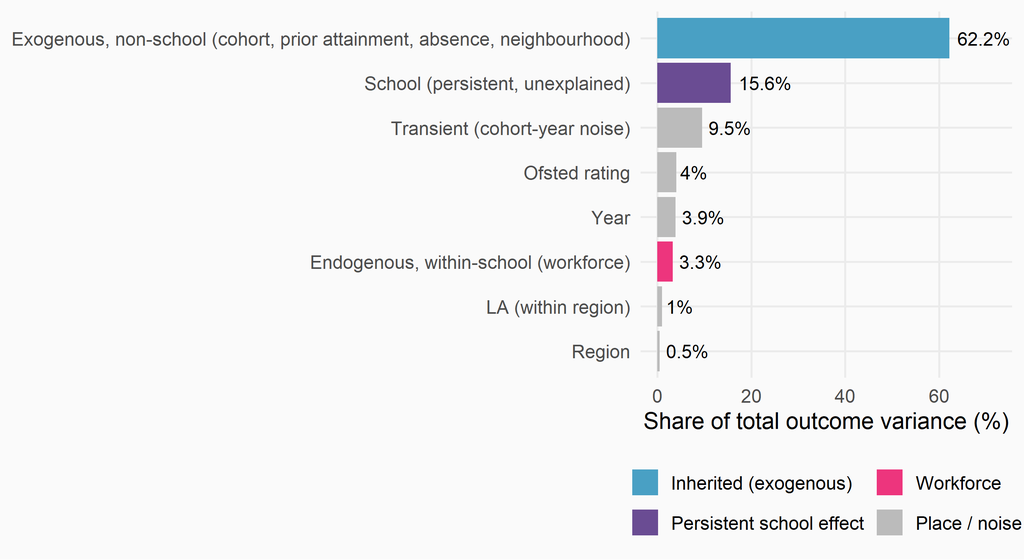

Workforce — the part schools directly control — is a sliver (3%) next to the hand they are dealt (62%). Even the *persistent school effect* (16%) is an upper bound bundling genuine school ethos/management etc. with other things they don’t control in their catchment, not otherwise measured e.g. cultural capital, parental motivation.

## …and for disadvantaged pupils — the group the policy targets

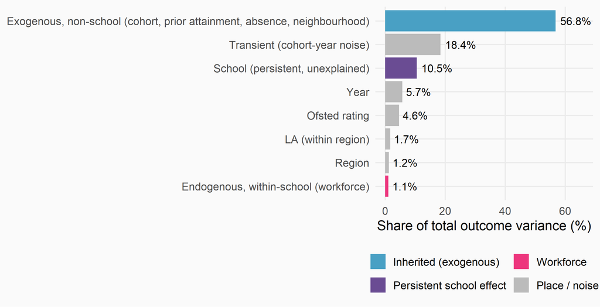

Even for disadvantaged pupils, workforce (school-controllable) is just **1.1%** vs **56.8%** inherited — the persistent school effect (10.5%) is still a dwarfed upper bound.

## What causes Attainment 8 to vary between schools?

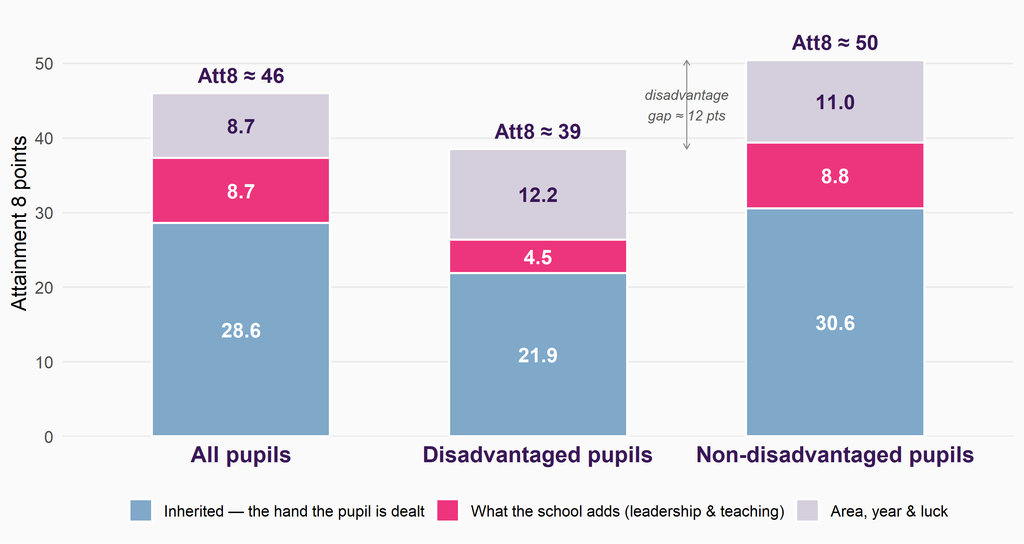

Figure 10

Bar height = each group’s average school-level score; each block = that factor’s share of the variation in school outcomes. The **pink** block — what leadership & teaching add — is real and visible for **all three groups**, and it is a **floor, not a ceiling**: a school like **BACA** adds ~1 SD *more* than the typical school for its disadvantaged pupils. *Figures are unweighted school-level averages (each school counts once); the pupil-weighted national gap is ~15 points.*

## So what does a better school add?

That pink slice was the school’s *share of the variation* — so what does a school **one step better than average** actually add to a disadvantaged pupil?

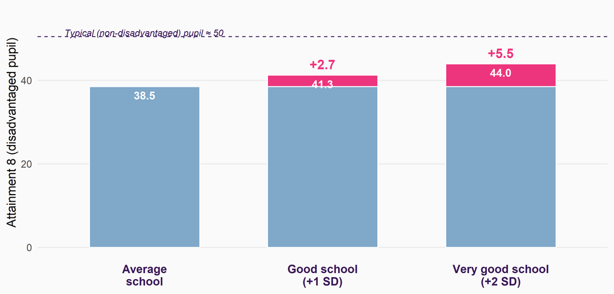

Figure 11

The school effect is **additive** — a good school adds its ~2.7 points *to the pink block*, a very good school ~5.5. A genuinely good school closes **a good part of the gap** to the typical non-disadvantaged pupil (~46% for the best) — the lever is real, but even the best schools cannot close it alone. **BACA does exactly this: +3.1 over four years.**

## The BACA paradox

**What people thought:**

- ‘Requires Improvement’ Ofsted
- Low raw attainment scores
- *Equity in Education* campaign from BACA Catchment:
  - “We want choice” **to not attend catchment school**
  - “A system which pays particular attention to the needs of children from disadvantaged areas”
- many parents (~50 families last year) opt for Patcham instead

**What the data shows:**

- **Best performing school in the city** for disadvantaged pupils
- +5 GCSE points above national peers (2024–25)
- April 2025: Ofsted upgraded to **‘Good’** in all areas

**Patcham — “the safer choice”:**

Parents, acting rationally on available information and vocal campaigning, may have been choosing the school with *lower* value-added for their children — if that is the most important factor.

Well intentioned but poorly informed campaign could have nudged parents into poor decisions.

## Attendance as a school-level lever

- **Patcham** is one of only **two** schools in the city with attendance better than the national average
- This is an *actionable lever* at the school level
- BACA exemplifies the national finding: schools with higher disadvantage can develop specialised, effective support
- Every school in the city could learn from Patcham on attendance — and from BACA on supporting disadvantaged pupils

The city needs to **disaggregate the attendance problem** — different causes require different strategies: family holidays, SEND challenges, transport barriers, caring responsibilities.

## Absence isn’t one thing — it’s two

- Absence in our headline model is a **single number**, but conceptually it sits in **two roles** at once
- Part of it is **structural** — driven by intake, family circumstances, area health, deprivation, SEN, EAL…
- Part of it is **school-managed** — pastoral systems, attendance officers, parental engagement, ethos around getting children into class
- A two-stage decomposition<sup>1</sup> separates these:
  - **Stage 1**: model expected absence from intake variables only
  - **Stage 2**: refit attainment using *expected* absence; what the school adds (including its attendance management) flows into the value-added residual

Most of school-level absence variance nationally is **structural**. The school-controllable share is the smaller part — but it is the share local policy can actually move.

[^1]: Full analysis: https://adamdennett.github.io/school_attainment_tool/model_experiments.html#sec-two-stage-absence

## Where do schools sit on the joint-signal plane?

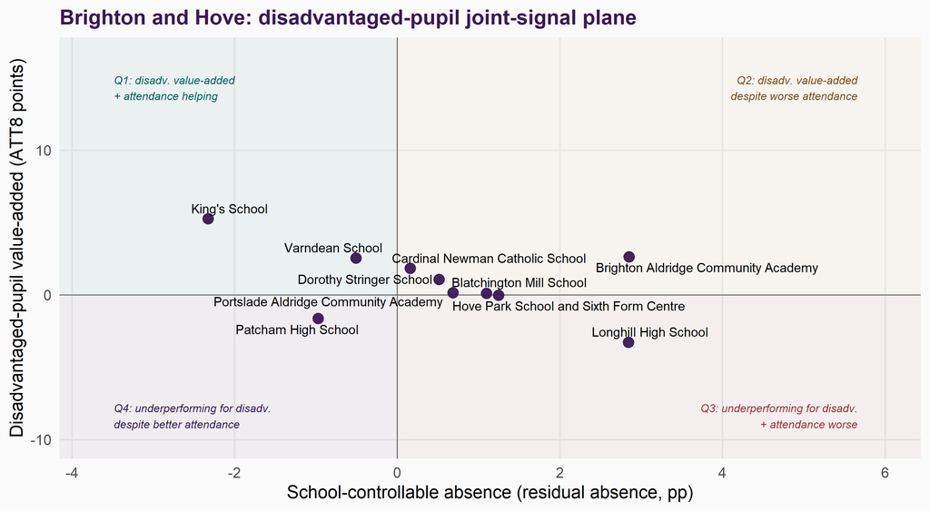

Figure 12

## What this view changes

- **BACA** sits firmly in **Q2** — adding value *despite* worse-than-predicted attendance. Closing its residual-absence gap would compound an already-strong pedagogical signal.
- **Patcham** sits in **Q4** — underperforming *despite* better-than-predicted attendance. The simple “fix attendance” story isn’t available here.
- Schools in **Q3** (underperforming + attendance worse) are the cleanest single-lever targets — both signals point the same way.
- Schools in **Q1** (adding value + attendance helping) are where the city should look for **practice worth sharing**.

Reading **value-added** alongside **residual absence** separates “this school adds points to attainment” from “this school’s pupils attend more than their intake predicts” — two distinct signals that single-residual league tables fold together.

# Discussion & Reflections

## The danger of single-lever policy thinking

- The council’s proposals were built on the premise that attainment was **“driven by economic advantage”**
- This premise is false in the context of the DfE’s own research (Macleod et al. 2015) — our modelling confirms this was **at best a flawed understanding**
- Concentrations of disadvantage are one of the **weaker** levers available
- For disadvantaged pupils specifically, the direction of effect **runs contrary** to the policy assumptions - across England over 4-years of data, disadvantaged pupils get better results in schools with higher concentrations of disadvantaged pupils
- The policy was pulling a lever with relatively little mechanical advantage while ignoring one with **considerably more**

## Second-order effects: the risks of the chosen lever

- The chosen policy if implemented as intended requires **longer journeys** for many children
- Thomson (2023): pupils who travel further to school are **absent more often**
- Given absence is the city’s **most acute problem** and the **strongest predictor** of attainment…

A policy that even marginally increases absence could be **counterproductive** in attainment terms. The claim of “almost no cost” for social mixing overlooks these second-order effects.

## Where we are now?

- Following opposition and appeals: PAN reductions rejected, 20% out-of-catchment → 5%.
- But the policy reverberations continue through:
  - **parental choices** already made
  - 2025/26 Proposed Sibling Link changes
- **Low levels of pupil displacement on 2026 offer day luck not judgement!**
- Underlying belief that current policy direction will benefit disadvantaged pupils in the city

## What should Brighton and Hove do?

The council has recently agreed to a **cross-party working group** on schools — a positive step. Our strongest recommendation:

**Priority one: a deep dive into absence.** The city has the 2nd worst absence rate in England but near-average disadvantage. This is not inevitable — it is, in principle, solvable.

The absence problem needs **disaggregating** — very different situations exist within the headline statistics:

- A few days missed for a family holiday by an otherwise well-attending pupil
- A SEND student who struggles with the school environment but has strong family support
- A student with caring responsibilities living far from school, struggling with bus journeys
- Post-pandemic disengagement and mental health challenges

Each requires a **different strategy**. Schools like Patcham — one of only two with attendance below the national average — offer lessons in what works locally.

- Be prepared for counter-intuitive outcomes (does increased absence in B&H current improve outcomes for those who do attend school through smaller class sizes and less disruptive behaviour?)

## Lessons for other LEAs

- Every LEA has a **different profile** of challenges — different positions along non-linear curves
- What works in one context may be **irrelevant or counterproductive** in another
- The DfE open data provides the **raw materials** for local understanding
- But there’s a crucial gap between **raw data** and **actionable intelligence**
- **National ambitions will founder** if pursued locally without adequate analytical infrastructure

# The Policy Simulator Tool

## Bridging the gap

**What it does:**

- Search for **any school** in England
- See key statistics and contextual benchmarks
- Compare **observed vs predicted** attainment
- **Simulate** the impact of changes to absence, FSM, workforce etc.
- Explore **LA-level** patterns and typologies
- Find a school’s contextual **“twin”**

**Built with:**

- R Shiny
- Same multilevel models as this analysis
- DfE open data (updated annually)
- Development accelerated by **Claude** (Anthropic) — AI4CI funded

Not the finished article — but a demonstration of what’s possible when open data + appropriate methods + accessible tools come together.

## The simulator in action

[figure not shown]

[figure not shown]

School Finder → select any school → view contextual statistics → send to the Policy Simulator

[adam-dennett.shinyapps.io/School_Attainment_Policy_Simulator](https://adam-dennett.shinyapps.io/School_Attainment_Policy_Simulator/)

## Adjusting policy levers

[figure not shown]

Non-linear effects mean the same adjustment produces **different impacts** depending on the school’s starting position

# Conclusions & Recommendations

## Key takeaways

1. School-level attainment is **remarkably predictable** (~80% variance explained) from a handful of open data variables
2. **Absence is the dominant predictor** — 2.6x more important than concentrations of disadvantage
3. For disadvantaged pupils, the concentration effect **runs in the opposite direction** to common assumption
4. For disadvantaged pupils the most important factor impacting their attainment is attendance
   - nearly 1/2 of school level performance is explained by attendance alone
   - and it matters almost twice as much for disadvantaged pupils than non-disadvantaged pupils.
5. Brighton & Hove is one of the **highest-performing LEAs** — but has the **2nd worst absence** in England
6. The 2024 policy was **pulling the wrong lever** — targeting the weaker factor while ignoring the stronger one
7. Crude metrics (raw league tables, single-word Ofsted) **mislead** parents and policy makers

## Recommendations

**For the DfE:**

- Invest in **analytical infrastructure** at the local level
- Fund **LA analytical capacity** or develop nationally maintained benchmarking tools
- Go **beyond raw league tables**

**For LEAs:**

- **Resist single causal narratives**
- The factors are multiple, interacting, non-linear, context-dependent
- Create institutional space for **genuine deliberation** before irreversible decisions
- Prioritise **attendance** as a policy lever

**For schools, governors & parents:**

- **Contextualised benchmarking** offers a fairer basis than raw scores
- Demand **better information** before making choices
- School ‘quality’ ≠ raw attainment

## The final word

**The caution:** Policy made in haste, anchored to a single causal narrative and implemented without adequate regard for evidence, risks doing more harm than good — particularly when it disrupts a system that is working well.

**The encouragement:** The raw materials for better policy **already exist** in DfE open data. With the right analytical tools and a commitment to evidence over ideology, it is possible to understand with considerable precision what drives attainment in any local context — and where the most productive interventions lie.

**The challenge:** Ensuring this understanding reaches decision makers in a usable form **before** decisions are made — not after.

## Links & resources

**The tool:**

🔗 [Policy Simulator](https://adam-dennett.shinyapps.io/School_Attainment_Policy_Simulator/)

**The analysis:**

🔗 [Full analysis & supplementary material](https://adamdennett.github.io/school_attainment_tool/)

**The code:**

🔗 [GitHub repository](https://github.com/adamdennett/school_attainment_tool)

**The paper:**

🔗 [Full report](https://adamdennett.github.io/school_attainment_tool/pulling_the_right_lever.html)

**Contact:**

📧 a.dennett@ucl.ac.uk

**Funding:**

🔗 [UKRI AI4CI Hub](https://ai4ci.ac.uk/) — National AI Research Hub for Collective Intelligence

All data used in this analysis are publicly available from the Department for Education. All processing code is open source.

[figure not shown]